# Modern Data Mining - HW 4

Group Member Bingying Feng

Group Member Dingzhe Leng

Group Member He Zhang

# Overview / Instructions

This is homework #4 of STAT 471/571/701. It will be **due on 21, April, 2019 by 11:59 PM** on Canvas. You can directly edit this file to add your answers. Submit the Rmd file, a PDF or word or HTML version with **only 1 submission** per HW team. No zip files please.

# Problem 0: Methods

Review the codes and concepts covered during lecture, in particular:

- Single trees, Bagging, Random Forest and Boosting
- Text Mining
- Basic Deep Learning elements

# Problem 1: IQ and successes

## Background: Measurement of Intelligence

Case Study: how intelligence relates to one’s future successes?

**Data needed: `IQ.Full.csv`**

ASVAB (Armed Services Vocational Aptitude Battery) tests have been used as a screening test for those who want to join the army or other jobs.

Our data set IQ.csv is a subset of individuals from the 1979 National Longitudinal Study of Youth (NLSY79) survey who were re-interviewed in 2006. Information about family, personal demographic such as gender, race and education level, plus a set of ASVAB (Armed Services Vocational Aptitude Battery) test scores are available. It is STILL used as a screening test for those who want to join the army! ASVAB scores were 1981 and income was 2005.

**Our goals:**

- Is IQ related to one’s successes measured by Income?
- Is there evidence to show that Females are under-paid?
- What are the best possible prediction models to predict future income?

**The ASVAB has the following components:**

- Science, Arith (Arithmetic reasoning), Word (Word knowledge), Parag (Paragraph comprehension), Numer (Numerical operation), Coding (Coding speed), Auto (Automative and Shop information), Math (Math knowledge), Mechanic (Mechanic Comprehension) and Elec (Electronic information).
- AFQT (Armed Forces Qualifying Test) is a combination of Word, Parag, Math and Arith.
- Note: Service Branch requirement: Army 31, Navy 35, Marines 31, Air Force 36, and Coast Guard 45,(out of 100 which is the max!)

**The detailed variable definitions:**

Personal Demographic Variables:

- Race: 1 = Hispanic, 2 = Black, 3 = Not Hispanic or Black
- Gender: a factor with levels “female” and “male”
- Educ: years of education completed by 2006

Household Environment:

- Imagazine: a variable taking on the value 1 if anyone in the respondent’s household regularly read magazines in 1979, otherwise 0
- Inewspaper: a variable taking on the value 1 if anyone in the respondent’s household regularly read newspapers in 1979, otherwise 0
- Ilibrary: a variable taking on the value 1 if anyone in the respondent’s household had a library card in 1979, otherwise 0
- MotherEd: mother’s years of education
- FatherEd: father’s years of education

Variables Related to ASVAB test Scores in 1981 (Proxy of IQ’s)

- AFQT: percentile score on the AFQT intelligence test in 1981
- Coding: score on the Coding Speed test in 1981
- Auto: score on the Automotive and Shop test in 1981
- Mechanic: score on the Mechanic test in 1981
- Elec: score on the Electronics Information test in 1981
- Science: score on the General Science test in 1981
- Math: score on the Math test in 1981
- Arith: score on the Arithmetic Reasoning test in 1981
- Word: score on the Word Knowledge Test in 1981
- Parag: score on the Paragraph Comprehension test in 1981
- Numer: score on the Numerical Operations test in 1981

Variable Related to Life Success in 2006

- Income2005: total annual income from wages and salary in 2005. We will use a natural log transformation over the income.

The following 10 questions are answered as 1: strongly agree, 2: agree, 3: disagree, 4: strongly disagree

- Esteem 1: “I am a person of worth”
- Esteem 2: “I have a number of good qualities”
- Esteem 3: “I am inclined to feel like a failure”
- Esteem 4: “I do things as well as others”
- Esteem 5: “I do not have much to be proud of”
- Esteem 6: “I take a positive attitude towards myself and others”
- Esteem 7: “I am satisfied with myself”
- Esteem 8: “I wish I could have more respect for myself”
- Esteem 9: “I feel useless at times”
- Esteem 10: “I think I am no good at all”

**Note: we will not use the Esteem scores in this homework.**

## 1. EDA: Some cleaning work is needed to organize the data.

- The first variable is the label for each person. Take that out.
- Take all the `Esteem` scores out for this homework
- Set categorical variables as factors
- Make log transformation for Income and take the original Income out
- Take the last person out of the dataset and label it as **Michelle**.
- When needed, split data to three portions: training, testing and validation (70%/20%/10%)

```r
data<-fread("H:/homework/ECON471 hw4/Homework 4/IQ.Full.csv")
summary(data)
```

```
##     Subject        Imagazine        Inewspaper        Ilibrary
##  Min.   :    2   Min.   :0.0000   Min.   :0.0000   Min.   :0.0000
##  1st Qu.: 1586   1st Qu.:0.0000   1st Qu.:1.0000   1st Qu.:1.0000
##  Median : 3108   Median :1.0000   Median :1.0000   Median :1.0000
##  Mean   : 3494   Mean   :0.7132   Mean   :0.8615   Mean   :0.7717
##  3rd Qu.: 4636   3rd Qu.:1.0000   3rd Qu.:1.0000   3rd Qu.:1.0000
##  Max.   :12140   Max.   :1.0000   Max.   :1.0000   Max.   :1.0000
##     MotherEd       FatherEd     FamilyIncome78       Race
##  Min.   : 0.0   Min.   : 0.00   Min.   :    0   Min.   :1.000
##  1st Qu.:11.0   1st Qu.:10.00   1st Qu.:11000   1st Qu.:3.000
##  Median :12.0   Median :12.00   Median :20000   Median :3.000
##  Mean   :11.7   Mean   :11.85   Mean   :21096   Mean   :2.781
##  3rd Qu.:12.0   3rd Qu.:14.00   3rd Qu.:27025   3rd Qu.:3.000
##  Max.   :20.0   Max.   :20.00   Max.   :75001   Max.   :3.000
##     Gender               Educ          Science          Arith
##  Length:2584        Min.   : 6.00   Min.   : 0.00   Min.   : 0.00
##  Class :character   1st Qu.:12.00   1st Qu.:13.00   1st Qu.:13.00
##  Mode  :character   Median :13.00   Median :17.00   Median :19.00
##                     Mean   :13.89   Mean   :16.25   Mean   :18.52
##                     3rd Qu.:16.00   3rd Qu.:20.00   3rd Qu.:25.00
##                     Max.   :20.00   Max.   :25.00   Max.   :30.00
##       Word           Parag          Numer           Coding
##  Min.   : 0.00   Min.   : 0.0   Min.   : 0.00   Min.   : 0.00
##  1st Qu.:23.00   1st Qu.:10.0   1st Qu.:28.00   1st Qu.:38.00
##  Median :28.00   Median :12.0   Median :36.00   Median :48.00
##  Mean   :26.56   Mean   :11.2   Mean   :35.32   Mean   :46.88
##  3rd Qu.:32.00   3rd Qu.:14.0   3rd Qu.:44.00   3rd Qu.:57.00
##  Max.   :35.00   Max.   :15.0   Max.   :50.00   Max.   :84.00
##       Auto            Math         Mechanic          Elec
##  Min.   : 0.00   Min.   : 0.0   Min.   : 0.00   Min.   : 0.00
##  1st Qu.:10.00   1st Qu.: 9.0   1st Qu.:11.00   1st Qu.: 9.00
##  Median :14.00   Median :13.0   Median :14.00   Median :12.00
##  Mean   :14.24   Mean   :14.2   Mean   :14.38   Mean   :11.58
##  3rd Qu.:18.00   3rd Qu.:20.0   3rd Qu.:18.00   3rd Qu.:15.00
##  Max.   :25.00   Max.   :25.0   Max.   :25.00   Max.   :20.00
##       AFQT          Income2005        Esteem1         Esteem2
##  Min.   :  0.00   Min.   :    63   Min.   :1.000   Min.   :1.000
##  1st Qu.: 31.48   1st Qu.: 23000   1st Qu.:1.000   1st Qu.:1.000
##  Median : 56.80   Median : 38231   Median :1.000   Median :1.000
##  Mean   : 54.44   Mean   : 49417   Mean   :1.426   Mean   :1.423
##  3rd Qu.: 78.07   3rd Qu.: 61000   3rd Qu.:2.000   3rd Qu.:2.000
##  Max.   :100.00   Max.   :703637   Max.   :4.000   Max.   :4.000
##     Esteem3        Esteem4        Esteem5         Esteem6
##  Min.   :1.00   Min.   :1.00   Min.   :1.000   Min.   :1.00
##  1st Qu.:3.00   1st Qu.:1.00   1st Qu.:3.000   1st Qu.:1.00
##  Median :4.00   Median :2.00   Median :4.000   Median :2.00
##  Mean   :3.51   Mean   :1.57   Mean   :3.452   Mean   :1.62
##  3rd Qu.:4.00   3rd Qu.:2.00   3rd Qu.:4.000   3rd Qu.:2.00
##  Max.   :4.00   Max.   :4.00   Max.   :4.000   Max.   :4.00
##     Esteem7        Esteem8         Esteem9         Esteem10
##  Min.   :1.00   Min.   :1.000   Min.   :1.000   Min.   :1.000
##  1st Qu.:1.00   1st Qu.:3.000   1st Qu.:3.000   1st Qu.:3.000
##  Median :2.00   Median :3.000   Median :3.000   Median :3.000
##  Mean   :1.75   Mean   :3.129   Mean   :3.162   Mean   :3.394
##  3rd Qu.:2.00   3rd Qu.:4.000   3rd Qu.:4.000   3rd Qu.:4.000
##  Max.   :4.00   Max.   :4.000   Max.   :4.000   Max.   :4.000
```

```r
data<-select(data,-Subject)
cols<-c("Esteem1","Esteem2","Esteem3","Esteem4","Esteem5",
        "Esteem6","Esteem7","Esteem8","Esteem9","Esteem10")
data<-select(data,-cols)
str(data)
```

```
## Classes 'data.table' and 'data.frame':   2584 obs. of  21 variables:
##  $ Imagazine     : int  1 0 1 1 1 1 1 1 1 1 ...
##  $ Inewspaper    : int  1 1 1 1 1 1 1 1 1 1 ...
##  $ Ilibrary      : int  1 1 1 1 1 1 1 1 1 1 ...
##  $ MotherEd      : int  5 12 12 9 12 12 12 12 12 12 ...
##  $ FatherEd      : int  8 12 12 6 10 16 12 15 16 18 ...
##  $ FamilyIncome78: int  20000 35000 8502 7227 17000 20000 48000 15000 4510 50000 ...
##  $ Race          : int  3 3 3 3 3 3 3 3 3 3 ...
##  $ Gender        : chr  "female" "male" "male" "female" ...
##  $ Educ          : int  12 16 12 14 14 16 13 13 13 17 ...
##  $ Science       : int  6 23 14 18 17 16 13 19 22 21 ...
##  $ Arith         : int  8 30 14 13 21 30 17 29 30 17 ...
##  $ Word          : int  15 35 27 35 28 29 30 33 35 28 ...
##  $ Parag         : int  6 15 8 12 10 13 12 13 14 14 ...
##  $ Numer         : int  29 45 32 24 40 36 49 35 48 39 ...
##  $ Coding        : int  52 68 35 48 46 30 58 58 61 54 ...
##  $ Auto          : int  9 21 13 11 13 21 11 18 21 18 ...
##  $ Math          : int  6 23 11 4 13 24 17 21 23 20 ...
##  $ Mechanic      : int  10 21 9 12 13 19 11 19 16 20 ...
##  $ Elec          : int  5 19 11 12 15 16 10 16 17 13 ...
##  $ AFQT          : num  6.84 99.39 47.41 44.02 59.68 ...
##  $ Income2005    : int  5500 65000 19000 36000 65000 8000 71000 43000 120000 64000 ...
##  - attr(*, ".internal.selfref")=<externalptr>
```

```r
data$log_FamilyIncome78<-log(data$FamilyIncome78)
data<-select(data,-FamilyIncome78)
data$log_Income2005<-log(data$Income2005)
data<-select(data,-Income2005)
cols2<-c("Imagazine","Inewspaper","Ilibrary","MotherEd","FatherEd",
         "Race","Gender","Educ")
data<-data %>% mutate_at(cols2, funs(factor(.)))
Michelle<-data[2584,]
data<-data[-2584,]

split1 <- initial_split(data, prop = .7)
training.data<- training(split1)
test  <- testing(split1)

split2 <- initial_split(test, prop = 2/3)
testing.data<- training(split2)
validate.data<- testing(split2)
```

## 2. Factors affect Income

We only use linear models to answer the questions below.

1. Is there any evidence showing ASVAB test scores might affect the Income. Show your work here.

```r
fit0.0<-lm(log_Income2005~1,data)
fit0.1<-lm(log_Income2005~Science+Arith+Word+Parag+Numer+Coding+Auto+Math+Mechanic+Elec+AFQT,data)
summary(fit0.1)
```

```
##
## Call:
## lm(formula = log_Income2005 ~ Science + Arith + Word + Parag +
##     Numer + Coding + Auto + Math + Mechanic + Elec + AFQT, data = data)
##
## Residuals:
##     Min      1Q  Median      3Q     Max
## -6.5348 -0.3766  0.1212  0.5360  2.7763
##
## Coefficients:
##              Estimate Std. Error t value Pr(>|t|)
## (Intercept)  9.544176   0.116910  81.637  < 2e-16 ***
## Science     -0.013725   0.007277  -1.886  0.05939 .
## Arith        0.005332   0.005850   0.911  0.36215
## Word        -0.012099   0.005437  -2.225  0.02614 *
## Parag       -0.016594   0.011430  -1.452  0.14668
## Numer        0.011880   0.002676   4.439 9.40e-06 ***
## Coding      -0.004256   0.001627  -2.616  0.00896 **
## Auto         0.041264   0.005559   7.423 1.55e-13 ***
## Math         0.018310   0.006831   2.680  0.00740 **
## Mechanic    -0.001073   0.006047  -0.178  0.85911
## Elec         0.017553   0.007812   2.247  0.02472 *
## AFQT         0.004949   0.002629   1.882  0.05989 .
## ---
## Signif. codes:  0 '***' 0.001 '**' 0.01 '*' 0.05 '.' 0.1 ' ' 1
##
## Residual standard error: 0.8984 on 2571 degrees of freedom
## Multiple R-squared:  0.1529, Adjusted R-squared:  0.1493
## F-statistic:  42.2 on 11 and 2571 DF,  p-value: < 2.2e-16
```

```r
anova(fit0.0,fit0.1)
```

```
## Analysis of Variance Table
##
## Model 1: log_Income2005 ~ 1
## Model 2: log_Income2005 ~ Science + Arith + Word + Parag + Numer + Coding +
##     Auto + Math + Mechanic + Elec + AFQT
##   Res.Df    RSS Df Sum of Sq      F    Pr(>F)
## 1   2582 2449.7
## 2   2571 2075.1 11    374.63 42.197 < 2.2e-16 ***
## ---
## Signif. codes:  0 '***' 0.001 '**' 0.01 '*' 0.05 '.' 0.1 ' ' 1
```

Yes. We run the regression on ASVAB test scores. The p-value in the test is very small, which indicates ASVAB test scores affect income significantly.\

2. Is there any evidence to show that there is gender bias against either male or female in terms of income. Once again show your work here.

```r
fit0.2<-lm(log_Income2005~Science+Arith+Word+Parag+Numer+Coding+Auto+Math+Mechanic+Elec+AFQT+Gender,data)
summary(fit0.2)
```

```
##
## Call:
## lm(formula = log_Income2005 ~ Science + Arith + Word + Parag +
##     Numer + Coding + Auto + Math + Mechanic + Elec + AFQT + Gender,
##     data = data)
##
## Residuals:
##     Min      1Q  Median      3Q     Max
## -6.6391 -0.3448  0.1172  0.5157  2.6528
##
## Coefficients:
##               Estimate Std. Error t value Pr(>|t|)
## (Intercept)  9.220e+00  1.160e-01  79.459  < 2e-16 ***
## Science     -1.371e-02  7.053e-03  -1.944  0.05201 .
## Arith        4.253e-03  5.670e-03   0.750  0.45328
## Word        -6.546e-04  5.343e-03  -0.123  0.90250
## Parag        7.158e-03  1.123e-02   0.637  0.52390
## Numer        1.256e-02  2.594e-03   4.843 1.35e-06 ***
## Coding      -4.307e-05  1.610e-03  -0.027  0.97866
## Auto         1.384e-02  5.791e-03   2.390  0.01693 *
## Math         1.937e-02  6.621e-03   2.925  0.00347 **
## Mechanic    -8.965e-03  5.892e-03  -1.521  0.12828
## Elec         2.518e-03  7.660e-03   0.329  0.74238
## AFQT         3.263e-03  2.552e-03   1.279  0.20109
## Gendermale   6.066e-01  4.693e-02  12.926  < 2e-16 ***
## ---
## Signif. codes:  0 '***' 0.001 '**' 0.01 '*' 0.05 '.' 0.1 ' ' 1
##
## Residual standard error: 0.8707 on 2570 degrees of freedom
## Multiple R-squared:  0.2046, Adjusted R-squared:  0.2009
## F-statistic:  55.1 on 12 and 2570 DF,  p-value: < 2.2e-16
```

```r
anova(fit0.1,fit0.2)
```

```
## Analysis of Variance Table
##
## Model 1: log_Income2005 ~ Science + Arith + Word + Parag + Numer + Coding +
##     Auto + Math + Mechanic + Elec + AFQT
## Model 2: log_Income2005 ~ Science + Arith + Word + Parag + Numer + Coding +
##     Auto + Math + Mechanic + Elec + AFQT + Gender
##   Res.Df    RSS Df Sum of Sq      F    Pr(>F)
## 1   2571 2075.1
## 2   2570 1948.4  1    126.68 167.09 < 2.2e-16 ***
## ---
## Signif. codes:  0 '***' 0.001 '**' 0.01 '*' 0.05 '.' 0.1 ' ' 1
```

Yes, we add Gender to our regression. This variable is very significant. What’s more, holding all else equal, male earns 60.6% percent more wages than female.\

We next build a few models for the purpose of prediction using all the information available. From now on you may use the three data sets setting (training/testing/validation) when it is appropriate. **You should not use Validation set in the process of building classifer ever. This should only be used to get the testing error at the end.**

## 3. Trees

1. fit1: tree(Income ~ Educ + Gender, data.train) with default set up
   1. Display the tree
   2. How many end nodes? Briefly explain how the estimation is obtained in each end nodes and describe the prediction equation
   3. Does it show interaction effect of Gender and Educ over Income?
   4. Predict Michelle’s income

```r
fit1<-tree(log_Income2005~Educ + Gender, training.data)
fit1
```

```
## node), split, n, deviance, yval
##       * denotes terminal node
##
## 1) root 1809 1752.0 10.420
##   2) Gender: female 886  889.8 10.090
##     4) Educ: 7,8,9,10,11,12,13,14,15 620  533.7  9.924 *
##     5) Educ: 16,17,18,19,20 266  298.5 10.480 *
##   3) Gender: male 923  674.3 10.740
##     6) Educ: 7,8,9,10,11,12,14,15 568  407.0 10.500 *
##     7) Educ: 6,13,16,17,18,19,20 355  184.6 11.110 *
```

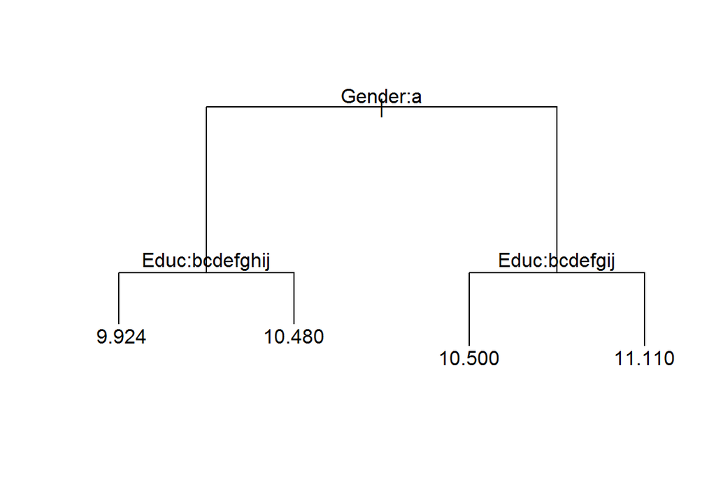

```r
# plot tree
plot(fit1)
text(fit1)
```

```r
yhat <-predict(fit1, Michelle)
yhat
```

```
##    2584
## 9.92413
```

2. fit2: fit2 <- rpart(Income2005 ~., data.train, minsplit=20, cp=.009)
   1. Display the tree using plot(as.party(fit2), main=“Final Tree with Rpart”)
   2. A brief summary of the fit2
   3. Compare testing errors between fit1 and fit2. Is the training error from fit2 always less than that from fit1? Is the testing error from fit2 always smaller than that from fit1?
   4. You may tune the fit2 settings to get a tree with small testing error (no need to try too hard.)

```r
fit2<-rpart(log_Income2005 ~.,training.data, minsplit=20, cp=.009)
fit2
```

```
## n= 1809
##
## node), split, n, deviance, yval
##       * denotes terminal node
##
##  1) root 1809 1752.24900 10.420380
##    2) Gender=female 886  889.78500 10.091220
##      4) Educ=7,8,9,10,11,12,13,14,15 620  533.66430  9.924130
##        8) AFQT< 18.5725 109  115.20720  9.468364 *
##        9) AFQT>=18.5725 511  390.98570 10.021350 *
##      5) Educ=16,17,18,19,20 266  298.46650 10.480670 *
##    3) Gender=male 923  674.31860 10.736350
##      6) Educ=7,8,9,10,11,12,14,15 568  407.03020 10.499690
##       12) Arith< 14.5 225  182.96820 10.180490
##         24) FatherEd=0,4,5,11,16 36   59.78971  9.570233 *
##         25) FatherEd=1,2,3,6,7,8,9,10,12,13,14,15,17,18,19 189  107.21790 10.296730 *
##       13) Arith>=14.5 343  186.09790 10.709080 *
##      7) Educ=6,13,16,17,18,19,20 355  184.57970 11.115000 *
```

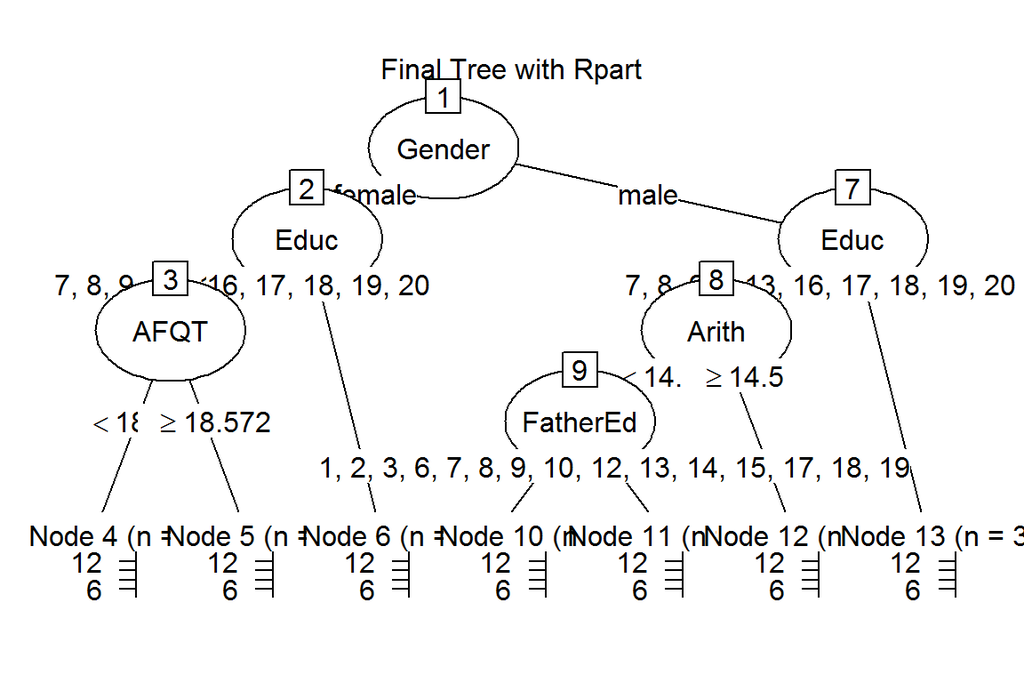

```r
# plot tree
plot(as.party(fit2), main="Final Tree with Rpart")
```

```r
##training error
mse.train.fit2 <-mean((training.data$log_Income2005-predict(fit2, training.data))^2)
mse.train.fit1 <-mean((training.data$log_Income2005-predict(fit1, training.data))^2)
mse.train.fit2
```

```
## [1] 0.7420369
```

```r
mse.train.fit1
```

```
## [1] 0.7870319
```

```r
##testing error
mse.test.fit2 <-mean((testing.data$log_Income2005-predict(fit2, testing.data))^2)
mse.test.fit1 <-mean((testing.data$log_Income2005-predict(fit1, testing.data))^2)
mse.test.fit2
```

```
## [1] 0.8544238
```

```r
mse.test.fit1
```

```
## [1] 0.8749265
```

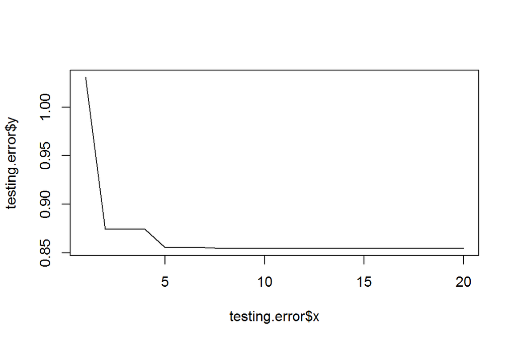

```r
##tune parameters
testing.error<-data.frame(x=1:20,y=rep(0,20))
for (i in 1:20){
fit2.1<-rpart(log_Income2005 ~.,training.data, minsplit=i, cp=.009)
testing.error[i,2]<-mean((testing.data$log_Income2005-predict(fit2.1, testing.data))^2)
}
plot(x=testing.error$x,y=testing.error$y,type="l")
```

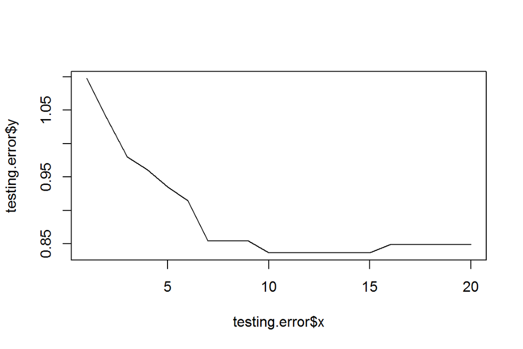

```r
testing.error<-data.frame(x=1:20,y=rep(0,20))
for (i in 1:20){
fit2.1<-rpart(log_Income2005 ~.,training.data, minsplit=20, cp=.001*i)
testing.error[i,2]<-mean((testing.data$log_Income2005-predict(fit2.1, testing.data))^2)
}
plot(x=testing.error$x,y=testing.error$y,type="l")
```

```r
fit2.final<-rpart(log_Income2005 ~.,training.data, minsplit=20, cp=.008)
```

3. Bag two trees: fit3
   1. Take 2 bootstrap training samples and build two trees using the rpart(Income2005 ~., data.train.b, minsplit=20, cp=.009). Display both trees.

```r
set.seed(200)
index1 <-sample(1:1809, 1809, replace=TRUE)
index2 <-sample(1:1809, 1809, replace=TRUE)
training.data.b1 <- training.data[index1,]
training.data.b2 <- training.data[index2,]

fit3.1<-rpart(log_Income2005 ~.,training.data.b1, minsplit=20, cp=.009)
fit3.1
```

```
## n= 1809
##
## node), split, n, deviance, yval
##       * denotes terminal node
##
##   1) root 1809 1872.693000 10.428390
##     2) Gender=female 887  929.499000 10.078120
##       4) Educ=7,8,9,10,11,12,14 498  419.158100  9.816803
##         8) FatherEd=2,3,5,8,11,15,18 110  121.195300  9.375501
##          16) MotherEd=4,5,7,8,13,15 41   48.501490  8.641817 *
##          17) MotherEd=9,10,11,12,14 69   37.509760  9.811459 *
##         9) FatherEd=0,1,4,6,7,9,10,12,13,14,16,17,20 388  270.467300  9.941914 *
##       5) Educ=13,15,16,17,18,19,20 389  432.801000 10.412650
##        10) FatherEd=3,4,7,9,10,12,19,20 198  295.341300 10.205840
##          20) Coding< 53.5 81  153.303900  9.829475
##            40) Elec>=14.5 9   60.635720  8.169731 *
##            41) Elec< 14.5 72   64.776350 10.036940 *
##          21) Coding>=53.5 117  122.619900 10.466410
##            42) Educ=13,15,20 48   54.005690 10.002670 *
##            43) Educ=16,17,18,19 69   51.110680 10.789010 *
##        11) FatherEd=5,6,8,11,13,14,15,16,17,18 191  120.213000 10.627030 *
##     3) Gender=male 922  729.674200 10.765360
##       6) Educ=7,8,9,10,11,12,14,15,19 581  475.844500 10.531690
##        12) Arith< 15.5 231  168.873100 10.221320
##          24) FatherEd=0,3,4,5,8,10,11,16 77  103.093400  9.784022 *
##          25) FatherEd=2,6,7,9,12,13,14,15,17,18,19 154   43.692430 10.439970 *
##        13) Arith>=15.5 350  270.034700 10.736520
##          26) MotherEd=3,4,5,6,7,10,11,12,13 265  212.124800 10.579310
##            52) Educ=10,14,19 53   97.749490 10.036410
##             104) Word< 27.5 9   16.359070  8.590010 *
##             105) Word>=27.5 44   58.710590 10.332260
##               210) AFQT>=86.687 12   31.486660  9.258315 *
##               211) AFQT< 86.687 32    8.193544 10.734990 *
##            53) Educ=11,12,15 212   94.848650 10.715030 *
##          27) MotherEd=8,9,14,15,16 85   30.939060 11.226670 *
##       7) Educ=13,16,17,18,20 341  168.052200 11.163500 *
```

[figure not shown]

```r
plot(as.party(fit3.1), main="Final Tree with Rpart")
```

```r
fit3.2<-rpart(log_Income2005 ~.,training.data.b2, minsplit=20, cp=.009)
fit3.2
```

```
## n= 1809
##
## node), split, n, deviance, yval
##       * denotes terminal node
##
##   1) root 1809 1602.898000 10.430110
##     2) Gender=female 918  810.403800 10.129920
##       4) Educ=8,9,10,11,12,14 494  377.877400  9.894257
##         8) MotherEd=4,7,8,9,15 94  110.095900  9.395225
##          16) FatherEd=3,11,15,18 18   18.218800  8.145764 *
##          17) FatherEd=0,1,5,6,7,8,9,10,12,14 76   57.120880  9.691150 *
##         9) MotherEd=1,3,5,6,10,11,12,13,14,16,17 400  238.871400 10.011530
##          18) Educ=9 8    8.865783  8.233790 *
##          19) Educ=10,11,12,14 392  204.206700 10.047810 *
##       5) Educ=13,15,16,17,18,19,20 424  373.127400 10.404490
##        10) Numer< 23.5 13    6.081808  9.320238 *
##        11) Numer>=23.5 411  351.279400 10.438780
##          22) MotherEd=9,14,18 38   32.787510  9.851951 *
##          23) MotherEd=0,8,10,11,12,13,15,16,17 373  304.072800 10.498560
##            46) FatherEd=3,4,6,8,10,12,13,15,16,18,19,20 319  276.271700 10.418560
##              92) Math< 8.5 27   32.928400  9.900581
##               184) Mechanic>=11 10   10.084500  8.823785 *
##               185) Mechanic< 11 17    4.428499 10.533990 *
##              93) Math>=8.5 292  235.429400 10.466450
##               186) FatherEd=3,4,6,13,16,20 83  115.826800 10.191900
##                 372) Coding>=68.5 11   41.426530  8.781310 *
##                 373) Coding< 68.5 72   49.168920 10.407410 *
##               187) FatherEd=8,10,12,15,18,19 209  110.861700 10.575480 *
##            47) FatherEd=5,7,9,11,14,17 54   13.695720 10.971210 *
##     3) Gender=male 891  624.533700 10.739400
##       6) Educ=7,8,9,10,11,12,14 538  358.806100 10.482480
##        12) Word< 12.5 51   73.594740  9.657145
##          24) FatherEd=0,5,6,7,8,10,11 24   38.974840  8.932509 *
##          25) FatherEd=2,3,4,9,12,14,16 27   10.815500 10.301270 *
##        13) Word>=12.5 487  246.832900 10.568910
##          26) log_FamilyIncome78< 7.489331 10    6.780013  9.167570 *
##          27) log_FamilyIncome78>=7.489331 477  220.003600 10.598290 *
##       7) Educ=13,15,16,17,18,19,20 353  176.091600 11.130970
##        14) Auto< 15.5 113   53.260120 10.820370 *
##        15) Auto>=15.5 240  106.797400 11.277210 *
```

[figure not shown]

```r
plot(as.party(fit3.2), main="Final Tree with Rpart")
```

```
c) What is the testing error for the bagged tree. Is it guaranteed that the testing error by bagging the two tree always smaller that either single tree?
```

```r
mse.test.bag<-mean(mean((testing.data$log_Income2005-predict(fit3.1, testing.data))^2),
     mean((testing.data$log_Income2005-predict(fit3.2, testing.data))^2))
mse.test.bag
```

```
## [1] 1.059709
```

No. Bagging can reduce the variance while maintaining similar bias. However, we cannot guarantee that each time the testing error by bagging the two tree is always smaller that either single tree.

4. Build a best possible RandomForest, call it fit4
   1. Show the process how you tune mtry and number of trees. Give a very high level explanation how fit4 is built.
   2. Compare the OOB errors form fit4 to the testing errors using your testing data. Are you convinced that OOB errors estimate testing error reasonably well.
   3. What is the predicted value for Michelle?

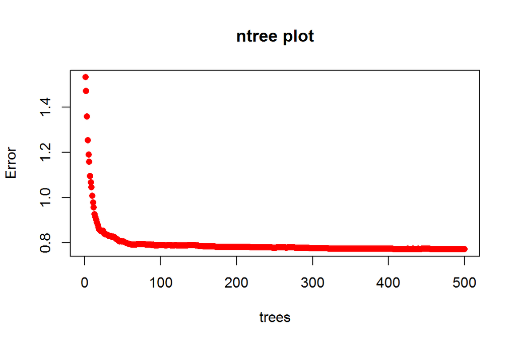

```r
training.data<-select(training.data,-log_FamilyIncome78)
fit.rf <-randomForest(log_Income2005~., training.data, mtry=10, ntree=500)
plot(fit.rf, col="red", pch=16, type="p", main="ntree plot")
```

We may need at least 100 trees to settle the OOB testing errors, so 500 trees are enough here. Now we fix ntree=500, We only want to compare the OOB mse[500] to see the mtry effects. Here we loopmtry from 1 to 19 and return the testing OOB errors

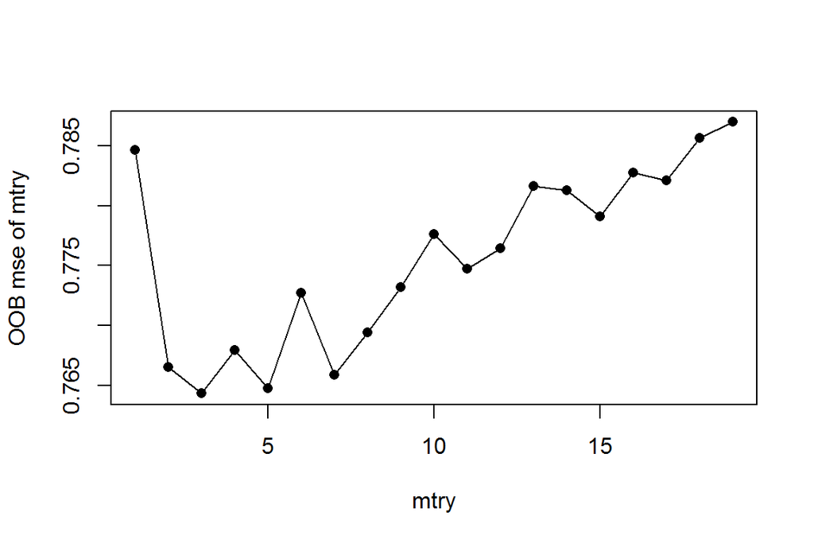

```r
rf.error.p <- 1:19# set up a vector of length 19
for(p in 1:19){
  fit.rf <-randomForest(log_Income2005~., training.data, mtry=p, ntree=500)
  rf.error.p[p] <- fit.rf$mse[500]
}
plot(1:19, rf.error.p, pch=16,xlab="mtry",ylab="OOB mse of mtry")
lines(1:19, rf.error.p)
```

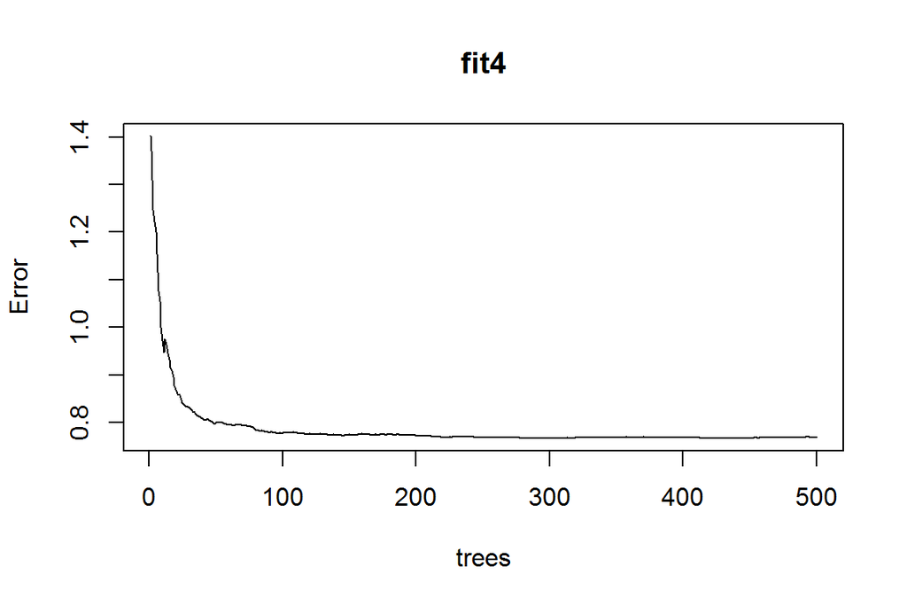

```r
fit4 <-randomForest(log_Income2005~., training.data, mtry=6, ntree=500)
plot(fit4)
```

```r
mse.oob <-mean((training.data$log_Income2005-fit4$predicted)^2)
mse.oob
```

```
## [1] 0.7687836
```

```r
mse.test <-mean((testing.data$log_Income2005-predict(fit4, testing.data))^2)
mse.test
```

```
## [1] 0.8630869
```

```r
yhat <-predict(fit4, Michelle)
yhat
```

```
##     2584
## 9.764179
```

22. Build a best possible boosting tree, call it fit5
    1. Once again show the process of how fit5 is built
    2. Report the testing error
    3. Report the predicted value for Michelle.

```r
#it takes too long time to run, so we didn't include it in our final file
# x <- 1:20# set up a vector of length 19
# for(p in 1:20){
#  fit.test <- gbm(
#   formula = log_Income2005~.,
#   distribution = "gaussian",
#   data = training.data,
#   n.trees = 1000*p,
#   interaction.depth = 2,
#   shrinkage = 0.001,
#   cv.folds = 5,
#   n.cores = NULL, # will use all cores by default
#   verbose = FALSE
#   )
# pred <- predict(fit.test, n.trees = fit.test$n.trees, testing.data)
# x[p]<-caret::RMSE(pred, testing.data$log_Income2005)
# }
# plot(1:20, x, pch=16,xlab="n.trees",ylab="OOB mse of n.trees")
# lines(1:20, x)

fit5 <- gbm(
  formula = log_Income2005~.,
  distribution = "gaussian",
  data = training.data,
  n.trees = 5000,
  interaction.depth = 1,
  shrinkage = 0.001,
  cv.folds = 10,
  n.cores = NULL, # will use all cores by default
  verbose = FALSE
  )
pred <- predict(fit5, n.trees = fit5$n.trees, testing.data)
caret::RMSE(pred, testing.data$log_Income2005)
```

```
## [1] 0.9174019
```

```r
yhat <- predict(fit5, n.trees = fit5$n.trees, Michelle)
yhat
```

```
## [1] 9.816609
```

6. Now you have built so many predicted models (fit1 through fit5 in this section). Summarize the results and nail down one best possible final model you will recommend to predict income. Explain briefly why this is the best choice. Finally for the first time evaluate the prediction error using the validating data set.

```r
mse.validate4 <-mean((validate.data$log_Income2005-predict(fit4, validate.data))^2)
mse.validate4
```

```
## [1] 0.5306295
```

```r
mse.validate5 <-mean((validate.data$log_Income2005-predict(fit5, validate.data))^2)
```

```
## Using 4998 trees...
```

```r
mse.validate5
```

```
## [1] 0.5186236
```

# Problem 2: Yelp review

(for more information check their website: http://www.yelp.com/dataset_challenge)

It is unlikely we will win the $5000 prize posted but we get to use their data for free. We have done a detailed analysis in our lecture. This exercise is designed for you to get hands on the whole process.

**Data needed: yelp_subset.csv available in Canvas…/Data/**

The goals are 1) Try to identify important words associated with positive ratings and negative ratings. Collectively we have a sentiment analysis. 2) To predict ratings using different methods.

1. Data and data split: Take a random sample of 20000 reviews (set.seed(1)) from our original data set. Extract document term matrix for texts to keep words appearing at least .5% of the time among all 20000 documents. Go through the similar process of cleansing as we did in the lecture.

```r
data.all<- fread("yelp_subset.csv", stringsAsFactors = FALSE)
dim(data.all) # 100,000 documents
```

```
## [1] 100000     10
```

```r
names(data.all);
```

```
##  [1] "user_id"      "review_id"    "text"         "votes.cool"
##  [5] "business_id"  "votes.funny"  "stars"        "date"
##  [9] "type"         "votes.useful"
```

Take a sample.

```r
set.seed(1)
index<-sample(100000,20000)
data<- data.all[index,]
```

```r
data.text<-data$text
data.text <- iconv(data.text,"UTF-8","UTF-8")
mycorpus1 <- VCorpus( VectorSource(data.text))
as.character(mycorpus1[[1]])
```

```
## [1] "This review is pretty overdue. \n\nIt was my last semester at UT and a group of 8 of us went for dinner on a Friday night. We tried to get there early (6:30) so we could get out of there in enough time to go home and get ready for a night out.\n\nTIMELINESS:\nIt took them an hour to seat us.…
```

### Cleaning

1. Change to lower case

```r
mycorpus2 <- tm_map(mycorpus1, content_transformer(tolower))
as.character(mycorpus2[[4]])
```

```
## [1] "so 3 stars may not sound like much.. but take into consideration that these 3 stars are for one cupcake!!! or maybe it means that each star = $1 and therefore one cupcake=$3 ..haha.. ok, i lied. one cupcake actually equals $3.25 ..kinda pricey for a cupcake, yea?? i agree. but.. i would have…
```

2. Remove some non-content words

```r
mycorpus3<- tm_map(mycorpus2, removeWords, stopwords("english"))
```

3. Remove punctuations

```r
mycorpus4 <- tm_map(mycorpus3, removePunctuation)
```

4. Remove numbers

```r
mycorpus5 <- tm_map(mycorpus4, removeNumbers)
```

5. Word stem

```r
mycorpus6 <- tm_map(mycorpus5, stemDocument, lazy = TRUE)
```

### Word Frequency Matrix

```r
dtm1 <- DocumentTermMatrix( mycorpus6 )   ## library = collection of words for all documents
```

Take a look at the dtm

```r
colnames(dtm1)[1:50] # the first 50 words in the bag
```

```
##  [1] "älskar"       "aïoli"        "aaa"
##  [4] "aaaaaa"              "aaaah"               "aaaand"
##  [7] "aaaawweeesssooommme" "aaaawwweesssommme"   "aaah"
## [10] "aaahhhhh"            "aaargh"              "aadladjac"
## [13] "aag"                 "aah"                 "aahh"
## [16] "aahhhhh"             "aammmaaazzzinnnnggg" "aangan"
## [19] "aardvark"            "aaron"               "aarp"
## [22] "ababa"               "abacaxi"             "aback"
## [25] "abalon"              "abandon"             "abasi"
## [28] "abat"                "abbey"               "abbi"
## [31] "abbott"              "abbrevi"             "abc"
## [34] "abdomen"             "abdomin"             "abdomnioplasti"
## [37] "abduct"              "abdul"               "abduljabbar"
## [40] "abe"                 "abel"                "aber"
## [43] "abercrombi"          "aberdeen"            "aberr"
## [46] "abhor"               "abhorr"              "abig"
## [49] "abigail"             "abil"
```

document 1 which is row1

```r
inspect(dtm1[1,])
```

```
## <<DocumentTermMatrix (documents: 1, terms: 35944)>>
## Non-/sparse entries: 160/35784
## Sparsity           : 100%
## Maximal term length: 945
## Weighting          : term frequency (tf)
## Sample             :
##     Terms
## Docs amaz bug come food get hour just pretti thing wait
##    1    5   3    3    6   4    3    3      4     3    4
```

#### Reduce size of bag

```r
threshold <- .005*length(mycorpus6)   # 0.5% of the total documents
words.005 <- findFreqTerms(dtm1, lowfreq=threshold)  # words appearing at least among 0.5% of the documents
length(words.005)
```

```
## [1] 1691
```

```r
#words.005[500:600]
```

```r
dtm.005<- DocumentTermMatrix(mycorpus6, control = list(dictionary = words.005))
dim(as.matrix(dtm.005))
```

```
## [1] 20000  1691
```

```r
#colnames(dtm.005)[1:50]
```

```
(i) Briefly explain what does this matrix record? What is the cell number at row 100 and column 405? What does it represent?
```

```r
colnames(dtm.005)[405]
```

```
## [1] "dark"
```

```r
as.matrix(dtm.005)[100,405]
```

```
## [1] 0
```

This matrix records the frequency of apprearance of the 1691 words in each review. For example, the name of column 405 is “dark” and the cell number at row 100 and column 405 is 0. This means that in the review No.100, the word “dark” appeared 0 time.

```
(ii) What is the sparsity of the dtm obtained here? What does that mean?
```

```r
dtm.005
```

```
## <<DocumentTermMatrix (documents: 20000, terms: 1691)>>
## Non-/sparse entries: 855262/32964738
## Sparsity           : 97%
## Maximal term length: 13
## Weighting          : term frequency (tf)
```

The sparsity is 97%, which means 97% of the cells are zero.

2. Set the stars as a two category response variable called rating to be “1” if review has 5,4 stars and “0” if review has 1,2,3 stars. Combine the variable rating with the dtm as a data frame called data2.

```r
## Combine the original data with the text matrix
data<- data%>% mutate(rating= ifelse(stars>=4,1,0)%>%as.factor())
data1.temp <- data.frame(data,as.matrix(dtm.005) )
dim(data1.temp)
```

```
## [1] 20000  1702
```

```r
names(data1.temp)[1:30]
```

```
##  [1] "user_id"      "review_id"    "text"         "votes.cool"
##  [5] "business_id"  "votes.funny"  "stars"        "date"
##  [9] "type"         "votes.useful" "rating"       "abl"
## [13] "absolut"      "accept"       "access"       "accommod"
## [17] "accompani"    "account"      "across"       "act"
## [21] "actual"       "add"          "addict"       "addit"
## [25] "admit"        "ador"         "adult"        "advantag"
## [29] "adventur"     "advic"
```

```r
# data2 consists of date, rating and all the top 1% words
data2 <- data1.temp[, c(1,8,10, 11:ncol(data1.temp))]
names(data2)[1:20]
```

```
##  [1] "user_id"      "date"         "votes.useful" "rating"
##  [5] "abl"          "absolut"      "accept"       "access"
##  [9] "accommod"     "accompani"    "account"      "across"
## [13] "act"          "actual"       "add"          "addict"
## [17] "addit"        "admit"        "ador"         "adult"
```

```r
dim(data2)
```

```
## [1] 20000  1695
```

```r
# write.csv(data2, "YELP_tm_freq.csv", row.names = FALSE)
```

Get a training data with 13000 reviews and the 5000 reserved as the testing data. Keep the rest (2000) as our validation data set.

```r
set.seed(1)
n <- nrow(data2)
train.index <- sample(n, 13000)
data2.train<- data2[train.index, -c(1:3)] # only keep rating and the texts
data2.rest <- data2[-train.index, -c(1:3)]
n <- nrow(data2.rest)
test.index<-sample(n,5000)
data2.test<- data2.rest[test.index,]
data2.val<- data2.rest[-test.index,]
names(data2.train)[1:10]
```

```
##  [1] "rating"    "abl"       "absolut"   "accept"    "access"
##  [6] "accommod"  "accompani" "account"   "across"    "act"
```

```r
dim(data2.train)
```

```
## [1] 13000  1692
```

3. Use the training data to get Lasso fit. Choose lambda.1se. Keep the result here.

```r
y <- data2.train$rating
#X <- as.matrix(data2.train[, -c(1)]) # we can use as.matrix directly here
#result.lasso <- cv.glmnet(X, y, alpha=0.99, family="binomial")  # 10 minutes in my MAC
#save(result.lasso, file="tm_lasso_result.RData")
X1 <- sparse.model.matrix(rating~., data=data2.train)[, -1]
dim(X1)
```

```
## [1] 13000  1691
```

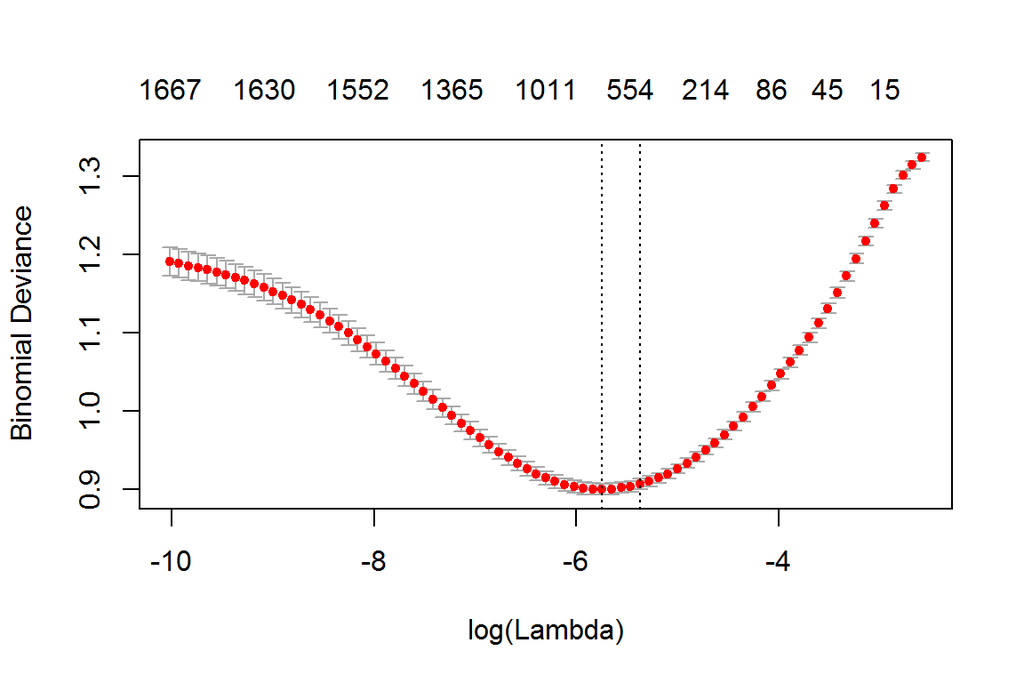

```r
result.lasso.1 <- cv.glmnet(X1, y, alpha=0.99, family="binomial")
plot(result.lasso.1)
```

```r
beta.lasso <- coef(result.lasso.1, s="lambda.1se")   # output lasso estimates
beta <- beta.lasso[which(beta.lasso !=0),] # non zero beta's
beta <- as.matrix(beta);
beta <- rownames(beta)
beta[2:51] #the first 50 words
```

```
##  [1] "abl"      "accept"   "account"  "across"   "act"      "add"
##  [7] "addict"   "admit"    "ador"     "advantag" "afford"   "agre"
## [13] "ahead"    "alon"     "alright"  "also"     "alway"    "amaz"
## [19] "anim"     "anoth"    "anywher"  "appar"    "appeal"   "artichok"
## [25] "asian"    "ask"      "atlanta"  "attempt"  "attitud"  "averag"
## [31] "avoid"    "awesom"   "babi"     "back"     "bad"      "bagel"
## [37] "balanc"   "bank"     "bare"     "barista"  "base"     "basement"
## [43] "bathroom" "beat"     "beauti"   "behind"   "berkeley" "best"
## [49] "better"   "biggest"
```

4. Feed the output from Lasso above, get a logistic regression.

```r
glm.input <- as.formula(paste("rating", "~", paste(beta[-1],collapse = "+"))) # prepare the formulae
result.glm <- glm(glm.input, family=binomial, data2.train )
```

1. Pull out all the positive coefficients and the corresponding words. Rank the coefficients in a decreasing order. Report the leading 2 words and the coefficients. Describe briefly the interpretation for those two coefficients.

```r
result.glm.coef <- coef(result.glm)
result.glm.coef<- sort(result.glm.coef,decreasing = T)
```

The leading two words and their coefficients are:

```r
head(result.glm.coef,2)
```

```
##     char    dream
## 1.729378 1.681757
```

The odds here is good rating (4,5) over bad rating (1,2,3). The change of odds is the exponential term of the log odds change.When the frequencies of other words are the same, a review with the word “char” has a log odds higher by 1.73, or an odds 5.64 times as high; a review with the word “dream” has a log odds higher by 1.68, or an odds 5.37 times as high.

2. Make a word cloud with the top 100 positive words according to their coefficients. Interpret the cloud briefly.

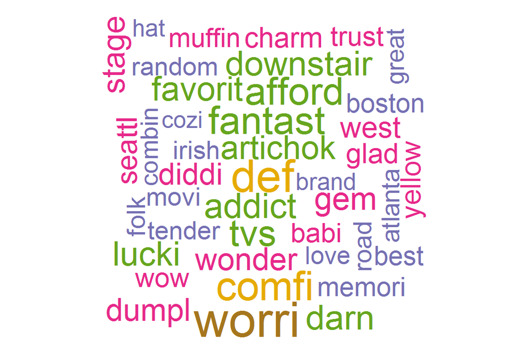

```r
# pick up the positive coef's which are positively related to the prob of being a good review
good.glm <- result.glm.coef[which(result.glm.coef > 0)]
good.glm <- good.glm[-1]  # took intercept out
cor.special <- brewer.pal(8,"Dark2")  # set up a pretty color scheme
good.fre <- sort(good.glm, decreasing = TRUE) # sort the coef's
good.word <- names(good.fre)  # good words with a decreasing order in the coeff's
wordcloud(good.word[1:100], good.fre[1:100],  # make a word cloud
          colors=cor.special, ordered.colors=F)
```

This word cloud shows the top 100 positive words related to a good rating. The larger the word, the stronger the positive correlation between the word and a good rating.

3. Repeat i) and ii) for the bag of negative words. The leading two words and their coefficients are:

```r
result.glm.coef<- sort(result.glm.coef,decreasing = F)
head(result.glm.coef,2)
```

```
##  overcook   mediocr
## -1.761261 -1.737329
```

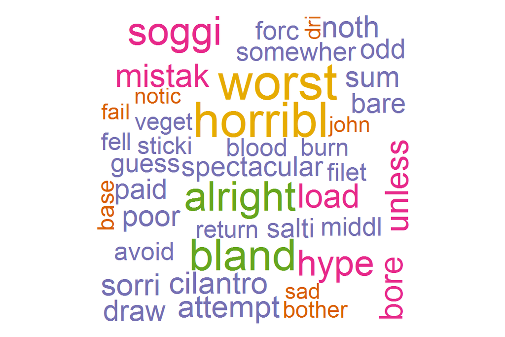

```r
# pick up the positive coef's which are positively related to the prob of being a good review
bad.glm <- result.glm.coef[which(result.glm.coef < 0)]
bad.glm <- bad.glm
cor.special <- brewer.pal(6,"Dark2")
bad.fre <- sort(-bad.glm, decreasing = TRUE) # sort the coef's
bad.word <- names(bad.fre)  # good words with a decreasing order in the coeff's
wordcloud(bad.word[1:100], bad.fre[1:100],  # make a word cloud
          colors=cor.special, ordered.colors=F)
```

This word cloud shows the top 100 negative words related to a good rating. The larger the word, the stronger the negative correlation between the word and a good rating.

```r
predict.lasso.p <- predict(result.lasso.1, as.matrix(data2.test[, -1]), type = "response", s="lambda.1se")
predict.lasso <- predict(result.lasso.1, as.matrix(data2.test[, -1]), type = "class", s="lambda.1se")
mean(data2.test$rating != predict.lasso)
```

```
## [1] 0.2078
```

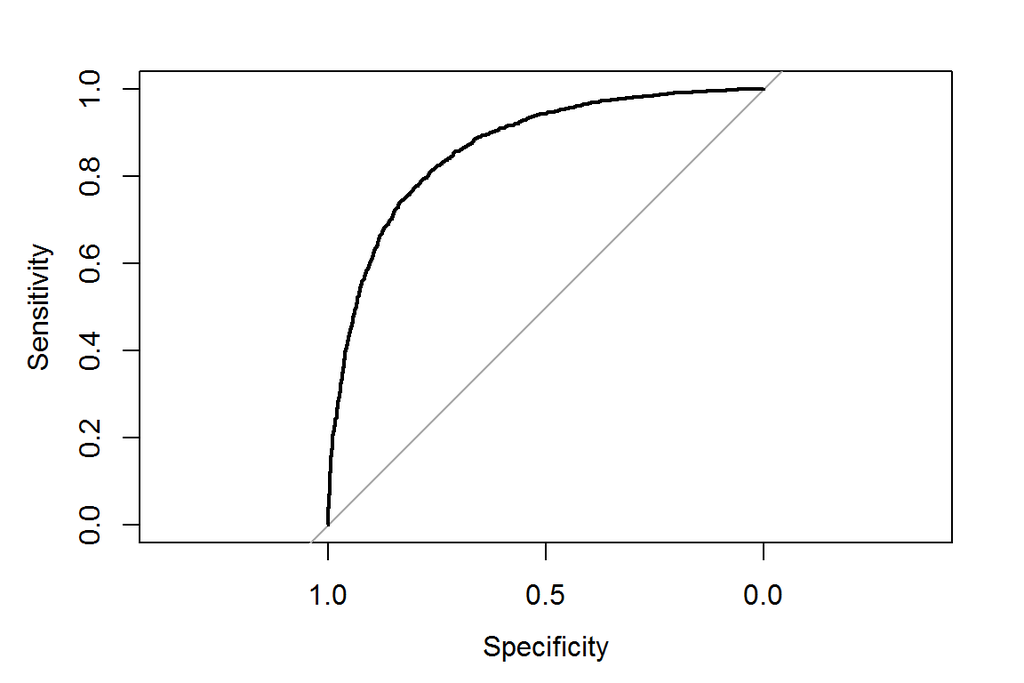

```
##
## Call:
## roc.default(response = data2.test$rating, predictor = predict.lasso.p,     plot = TRUE)
##
## Data: predict.lasso.p in 1924 controls (data2.test$rating 0) < 3076 cases (data2.test$rating 1).
## Area under the curve: 0.8655
```

```r
pROC::roc(data2.test$rating, predict.lasso.p, plot=TRUE)
```

```r
predict.glm <- predict(result.glm, data2.test, type = "response")
class.glm <- rep("0", 10000)
class.glm[predict.glm > .5] ="1"
testerror.glm <- mean(data2.test$rating != class.glm)
testerror.glm
```

```
## [1] 0.21
```

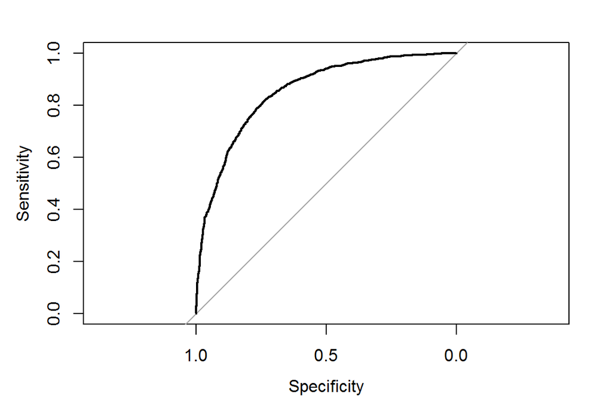

```
##
## Call:
## roc.default(response = data2.test$rating, predictor = predict.glm,     plot = T)
##
## Data: predict.glm in 1924 controls (data2.test$rating 0) < 3076 cases (data2.test$rating 1).
## Area under the curve: 0.8534
```

```r
pROC::roc(data2.test$rating, predict.glm, plot=T)
```

6. Now train the data using the training data set by RF. Get the testing error. Also explain how the RF works and how you tune the tuning parameters.

```r
#fit.rf.ranger <- ranger::ranger(rating~., data2.train, num.trees = 200, importance="impurity") # no plotting fun
#fit.rf.ranger <- ranger::ranger(rating~., data2.train, num.trees = 100, importance="impurity") # no plotting fun
#fit.rf.ranger <- ranger::ranger(rating~., data2.train, num.trees = 300, importance="impurity") # no plotting fun
fit.rf.ranger <- ranger::ranger(rating~., data2.train, num.trees = 500, importance="impurity") # no plotting fun
fit.rf.ranger
```

```
## Ranger result
##
## Call:
##  ranger::ranger(rating ~ ., data2.train, num.trees = 500, importance = "impurity")
##
## Type:                             Classification
## Number of trees:                  500
## Sample size:                      13000
## Number of independent variables:  1691
## Mtry:                             41
## Target node size:                 1
## Variable importance mode:         impurity
## Splitrule:                        gini
## OOB prediction error:             21.72 %
```

The default of mtry is the square root of `p` as a rule of thumb, so it is 41 here. I tried num.trees= 100,200,300,500, and ended up with 500 for a smaller OOB error.

Showing the most important variables:

```r
imp <- importance(fit.rf.ranger)
imp[order(imp, decreasing = T)][1:20]
```

```
##    great     love   delici      bad     best     amaz     food   decent
## 86.54046 73.12930 68.02612 44.23271 43.16028 42.84584 42.49214 40.11297
##  mediocr  favorit     noth  terribl    bland   better    alway    worst
## 39.82011 39.52532 37.19443 36.90934 35.62366 32.05316 30.19894 30.14210
##   awesom     okay    order     like
## 29.57296 29.28867 28.02606 27.46557
```

```r
#fit.rf.ranger$confusion # gives us the confusion matrix for the last forest!
predict.rf <- predict(fit.rf.ranger, data=data2.test, type="response")  # output the classes by majority vote
mean(data2.test$rating != predict.rf$predictions)
```

```
## [1] 0.214
```

7. Now train the data using Boosting. Get the testing error Use gbm to do boosting.

```r
#used xgboost
y<- as.numeric(as.character(y))
dtrain <- xgb.DMatrix(data = X1, label = y)
bst <- xgboost(data = dtrain, max_depth = 2, eta = 1, nthread = 2, nrounds = 100, objective = "binary:logistic")
#tried larger nrounds. The training error keeps decreasing but the testing error stays similar.
```

```r
X2 <- sparse.model.matrix(rating~., data=data2.test)[, -1]
y2<- data2.test$rating
y2<- as.numeric(as.character(y2))
pred <- predict(bst, X2)
prediction <- as.numeric(pred > 0.5)
test.error <- mean(as.numeric(pred > 0.5) != y2)
print(paste("test-error=", test.error))
```

```
## [1] "test-error= 0.2244"
```

8. If you can train a neural net with two layers with a reasonable number of neutrons in each layer (say 20). You could try a different number of layers and different number of neutrons and see how the results change. Settle down on one final architecture. Report the testing errors.

```r
#model.1
model.1 <- keras_model_sequential() %>%
  layer_dense(units = 20, activation = "relu", input_shape = c(1691)) %>%
  layer_dense(units = 1, activation = "sigmoid")
print(model.1)
```

```
## Model
## ___________________________________________________________________________
## Layer (type)                     Output Shape                  Param #
## ===========================================================================
## dense (Dense)                    (None, 20)                    33840
## ___________________________________________________________________________
## dense_1 (Dense)                  (None, 1)                     21
## ===========================================================================
## Total params: 33,861
## Trainable params: 33,861
## Non-trainable params: 0
## ___________________________________________________________________________
```

```r
model.1 %>% compile(
  optimizer = "rmsprop",
  loss = "binary_crossentropy",
  metrics = c("accuracy")
)
```

```r
#model.2
model.2 <- keras_model_sequential() %>%
  layer_dense(units = 20, activation = "relu", input_shape = c(1691)) %>%
  layer_dense(units = 20, activation = "relu") %>%
  layer_dense(units = 1, activation = "sigmoid")
print(model.2)
```

```
## Model
## ___________________________________________________________________________
## Layer (type)                     Output Shape                  Param #
## ===========================================================================
## dense_2 (Dense)                  (None, 20)                    33840
## ___________________________________________________________________________
## dense_3 (Dense)                  (None, 20)                    420
## ___________________________________________________________________________
## dense_4 (Dense)                  (None, 1)                     21
## ===========================================================================
## Total params: 34,281
## Trainable params: 34,281
## Non-trainable params: 0
## ___________________________________________________________________________
```

```r
model.2 %>% compile(
  optimizer = "rmsprop",
  loss = "binary_crossentropy",
  metrics = c("accuracy")
)
```

```r
#convert validation and testing data to matrix and labels
X.train<- model.matrix(rating~., data=data2.train)[, -1]
y.train<- as.numeric(as.character(data2.train$rating))
X.test<- model.matrix(rating~., data=data2.test)[, -1]
y.test<- as.numeric(as.character(data2.test$rating))
```

I set up a small validation set from the training data, as the `data2.val` should be reserved to the very end of this probelm set.

```r
#Set up validation set
val_indices <- 1:6000
x_val <- X.train[val_indices,]
partial_x_train <- X.train[-val_indices,]

y_val <- y.train[val_indices]
partial_y_train <- y.train[-val_indices]
```

```r
#fit models
fit1 <- model.1 %>% fit(
  partial_x_train,
  partial_y_train,
  epochs = 10,
  batch_size = 512,
  validation_data = list(x_val, y_val)
)
```

```r
fit1 <- model.2 %>% fit(
  partial_x_train,
  partial_y_train,
  epochs = 10,
  batch_size = 512,
  validation_data = list(x_val, y_val)
)
```

```r
model <- keras_model_sequential() %>%
  layer_dense(units = 20, activation = "relu", input_shape = c(1691)) %>%
  layer_dense(units = 1, activation = "sigmoid")

model %>% compile(
  optimizer = "rmsprop",
  loss = "binary_crossentropy",
  metrics = c("accuracy")
)

model %>% fit(X.train, y.train, epochs = 5, batch_size = 512)
```

```r
NNpred<- model %>% predict(X.test)
NNpredict<-  as.numeric(NNpred > 0.5)
mean(NNpredict!=y.test)
```

```
## [1] 0.1978
```

9. Which classifier(s) seem to produce the least testing error? Are you surprised? Report the final model and accompany the validation error. Once again this is THE only time you use the validation data set. For the purpose of prediction, comment on how would you predict a rating if you are given a review using our final model?

The neural net classifier seems to produce the least testing error. The final model is:

```r
print(model)
```

```
## Model
## ___________________________________________________________________________
## Layer (type)                     Output Shape                  Param #
## ===========================================================================
## dense_5 (Dense)                  (None, 20)                    33840
## ___________________________________________________________________________
## dense_6 (Dense)                  (None, 1)                     21
## ===========================================================================
## Total params: 33,861
## Trainable params: 33,861
## Non-trainable params: 0
## ___________________________________________________________________________
```

```r
X.val<- model.matrix(rating~., data=data2.val)[, -1]
y.val<- as.numeric(as.character(data2.val$rating))

NNpred.val<- model %>% predict(X.val)
NNpredict.val<- as.numeric(NNpred.val > 0.5)
mean(NNpredict.val!=y.val)
```

```
## [1] 0.201
```